# Assignment 612.1 NL - Gapminder Dataset

Nick Lesniak

March 15, 2016

Increased per capita GDP has been associated with increased health care expenditures[^1]. Additionally, increased health care expenditures have been shown to increase life expectancy[^2]. Therefore, does the change in per capita GDP positively correlate with the change in life expectancy? To test this relationship, we will investigate the relationship between the change in per capita GDP and life expectancy in 142 countries between 1952 and 2007 from the gapminder dataset.

```r
# Number of countries
length(levels(gapminder_data$country))
```

```
## [1] 142
```

```r
# Data collected from the years:
unique(gapminder_data$year)
```

```
##  [1] 1952 1957 1962 1967 1972 1977 1982 1987 1992 1997 2002 2007
```

If this positive correlation is true, we would expect greater increases in per capita GDP to be associated with greater increases in life expectancy.

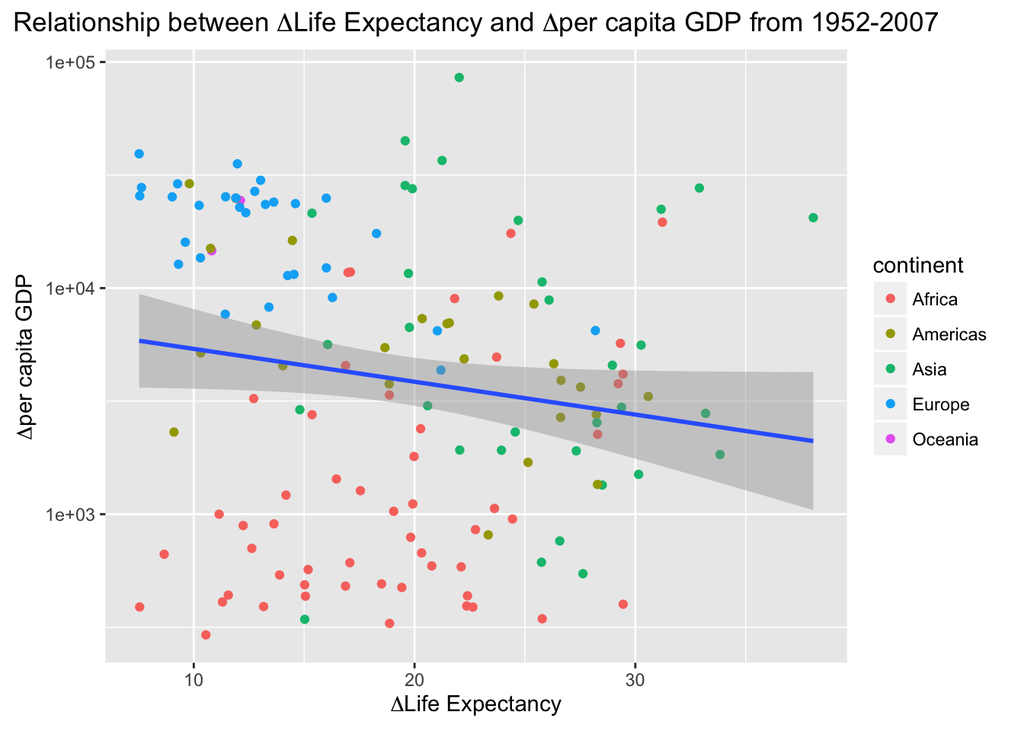

However, the trend observed in this data set does not support that the change in per capita GDP positively correlates with the change in life expectancy. Many factors may be able to account for this lack positive relationship. One such factor which this dataset does not take into account is the portion of the GDP per capita that used for health care expeditures. More data is needed to improve our understanding of this relationship.

[^1]: Sulku, SN., Caner, A. Health care expenditures and gross domestic product: the Turkish case. 2011 Feb;12(1):29-38. [PubMed](http://www.ncbi.nlm.nih.gov/pubmed/20151170)
[^2]: Mackenbach, JP., et al. Sharp upturn of life expectancy in the Netherlands: effect of more health care for the elderly? Eur J Epidemiology. 2011 Dec;26(12):903-14. [PubMed](http://www.ncbi.nlm.nih.gov/pubmed/22127495)